Data Science 383 Final Project: Playing with Data Science and Video Game Data

4/30/2020

Contributors: Tim Hanneman Jonathan Welham

# **Introduction:**

##### *Dataset:*

Motivated by Gregory Smith's web scrape of VGChartz Video Games Sales, this data set simply extends the number of variables with another web scrape from Metacritic. Unfortunately, there are missing observations as Metacritic only covers a subset of the platforms. Also, a game may not have all the observations of the additional variables discussed below. Complete cases are ~ 6,900

The dataset used in this report was downloaded from Kaggle (https://www.kaggle.com/rush4ratio/video-game-sales-with-ratings)

*Downloaded at*: 4/31/2020 3:20PM

##### *Goal:*

In this report the goal is to predict JP_Sales (in millions of units sold) based on other data from the dataset.

##### *Features:*

- *Name* - Name of the game
- *Platform* - Console on which the game is running
- *Year_of_Release* - Year of the game released
- *Genre* - Game's category
- *Publisher* - Publisher
- *NA_Sales* - Game sales in North America (in millions of units)
- *EU_Sales* - Game sales in the European Union (in millions of units)
- *JP_Sales* - Games sales in Japan (in millions of units)
- *Other_Sales* - Game sales in the rest of the world, i.e. Africa, Asia excluding Japan, Australia, Europe excluding the E.U. and South America (in millions of units)
- *Global_Sales* - Total sales in the world (in millions of units)
- *Critic_Score* - Aggregate score compiled by Metacritic staff
- *Critic_Count* - The number of critics used in coming up with the Critic_score
- *User_Score* - Score by Metacritic's subscribers
- *User_Count* - Number of users who gave the user_score
- *Developer* - Party responsible for creating the game
- *Rating* - The ESRB ratings (E.g. Everyone, Teen, Adults Only..etc)

```python
#Imports
import numpy as np
import pandas as pd
import matplotlib.pyplot as plt
import seaborn as sns
from sklearn.model_selection import train_test_split
from sklearn.tree import export_graphviz, DecisionTreeRegressor
from sklearn import tree
import graphviz
import warnings
from sklearn import metrics
warnings.filterwarnings("ignore")
from sklearn.ensemble import RandomForestClassifier
from sklearn.model_selection import learning_curve
from matplotlib.pyplot import show
from sklearn.metrics import silhouette_score
from sklearn.cluster import KMeans
from scipy.stats import zscore
from scipy.cluster.hierarchy import dendrogram, linkage
import matplotlib.pyplot as plt
from scipy import cluster
from scipy.spatial.distance import pdist
from sklearn.naive_bayes import GaussianNB
from sklearn.linear_model import LinearRegression
from sklearn import datasets, linear_model
from sklearn.model_selection import cross_val_score
from sklearn.metrics import accuracy_score
from sklearn.metrics import classification_report
from sklearn.metrics import mean_squared_error
from sklearn.tree import DecisionTreeClassifier
```

```python
from google.colab import drive
drive.mount('/content/drive')
```

# **Initial Data Exploration**

```python
df = pd.read_csv("/content/drive/Shared drives/data_sci/Video_Games_Sales_as_at_22_Dec_2016.csv")
#df = read_csv('/content/drive/My Drive/Third ')
#df = df.sort_index()
games = df.copy()
games.info()
df.head()
```

```
<class 'pandas.core.frame.DataFrame'>
RangeIndex: 16719 entries, 0 to 16718
Data columns (total 16 columns):
 #   Column           Non-Null Count  Dtype
---  ------           --------------  -----
 0   Name             16717 non-null  object
 1   Platform         16719 non-null  object
 2   Year_of_Release  16450 non-null  float64
 3   Genre            16717 non-null  object
 4   Publisher        16665 non-null  object
 5   NA_Sales         16719 non-null  float64
 6   EU_Sales         16719 non-null  float64
 7   JP_Sales         16719 non-null  float64
 8   Other_Sales      16719 non-null  float64
 9   Global_Sales     16719 non-null  float64
 10  Critic_Score     8137 non-null   float64
 11  Critic_Count     8137 non-null   float64
 12  User_Score       10015 non-null  object
 13  User_Count       7590 non-null   float64
 14  Developer        10096 non-null  object
 15  Rating           9950 non-null   object
dtypes: float64(9), object(7)
memory usage: 2.0+ MB
```

|  | Name | Platform | Year_of_Release | Genre | Publisher | NA_Sales | EU_Sales | JP_Sales | Other_Sales | Global_Sales | Critic_Score | Critic_Count | User_Score | User_Count | Developer | Rating |
| --- | --- | --- | --- | --- | --- | --- | --- | --- | --- | --- | --- | --- | --- | --- | --- | --- |
| 0 | Wii Sports | Wii | 2006.0 | Sports | Nintendo | 41.36 | 28.96 | 3.77 | 8.45 | 82.53 | 76.0 | 51.0 | 8 | 322.0 | Nintendo | E |
| 1 | Super Mario Bros. | NES | 1985.0 | Platform | Nintendo | 29.08 | 3.58 | 6.81 | 0.77 | 40.24 | NaN | NaN | NaN | NaN | NaN | NaN |
| 2 | Mario Kart Wii | Wii | 2008.0 | Racing | Nintendo | 15.68 | 12.76 | 3.79 | 3.29 | 35.52 | 82.0 | 73.0 | 8.3 | 709.0 | Nintendo | E |
| 3 | Wii Sports Resort | Wii | 2009.0 | Sports | Nintendo | 15.61 | 10.93 | 3.28 | 2.95 | 32.77 | 80.0 | 73.0 | 8 | 192.0 | Nintendo | E |
| 4 | Pokemon Red/Pokemon Blue | GB | 1996.0 | Role-Playing | Nintendo | 11.27 | 8.89 | 10.22 | 1.00 | 31.37 | NaN | NaN | NaN | NaN | NaN | NaN |

```python
games.describe()
```

|  | Year_of_Release | NA_Sales | EU_Sales | JP_Sales | Other_Sales | Global_Sales | Critic_Score | Critic_Count | User_Count |
| --- | --- | --- | --- | --- | --- | --- | --- | --- | --- |
| count | 16450.000000 | 16719.000000 | 16719.000000 | 16719.000000 | 16719.000000 | 16719.000000 | 8137.000000 | 8137.000000 | 7590.000000 |
| mean | 2006.487356 | 0.263330 | 0.145025 | 0.077602 | 0.047332 | 0.533543 | 68.967679 | 26.360821 | 162.229908 |
| std | 5.878995 | 0.813514 | 0.503283 | 0.308818 | 0.186710 | 1.547935 | 13.938165 | 18.980495 | 561.282326 |
| min | 1980.000000 | 0.000000 | 0.000000 | 0.000000 | 0.000000 | 0.010000 | 13.000000 | 3.000000 | 4.000000 |
| 25% | 2003.000000 | 0.000000 | 0.000000 | 0.000000 | 0.000000 | 0.060000 | 60.000000 | 12.000000 | 10.000000 |
| 50% | 2007.000000 | 0.080000 | 0.020000 | 0.000000 | 0.010000 | 0.170000 | 71.000000 | 21.000000 | 24.000000 |
| 75% | 2010.000000 | 0.240000 | 0.110000 | 0.040000 | 0.030000 | 0.470000 | 79.000000 | 36.000000 | 81.000000 |
| max | 2020.000000 | 41.360000 | 28.960000 | 10.220000 | 10.570000 | 82.530000 | 98.000000 | 113.000000 | 10665.000000 |

Some of the sales data is registering as zero. This is going to need some more investigation as to what is happening.

```python
games['Platform'].unique()
```

```
array(['Wii', 'NES', 'GB', 'DS', 'X360', 'PS3', 'PS2', 'SNES', 'GBA',
       'PS4', '3DS', 'N64', 'PS', 'XB', 'PC', '2600', 'PSP', 'XOne',
       'WiiU', 'GC', 'GEN', 'DC', 'PSV', 'SAT', 'SCD', 'WS', 'NG', 'TG16',
       '3DO', 'GG', 'PCFX'], dtype=object)
```

```python
games['Year_of_Release'].unique() #Replace nan with median year?
```

```
array([2006., 1985., 2008., 2009., 1996., 1989., 1984., 2005., 1999.,
       2007., 2010., 2013., 2004., 1990., 1988., 2002., 2001., 2011.,
       1998., 2015., 2012., 2014., 1992., 1997., 1993., 1994., 1982.,
       2016., 2003., 1986., 2000.,   nan, 1995., 1991., 1981., 1987.,
       1980., 1983., 2020., 2017.])
```

The null years should be dealt with. Depending on how many there are will affect what is done with them.

```python
games['Genre'].unique()                 #Replace nan with other?
```

```
array(['Sports', 'Platform', 'Racing', 'Role-Playing', 'Puzzle', 'Misc',
       'Shooter', 'Simulation', 'Action', 'Fighting', 'Adventure',
       'Strategy', nan], dtype=object)
```

```python
games['User_Score'].unique()                #TBD needs to be dealt with
```

```
array(['8', nan, '8.3', '8.5', '6.6', '8.4', '8.6', '7.7', '6.3', '7.4',
       '8.2', '9', '7.9', '8.1', '8.7', '7.1', '3.4', '5.3', '4.8', '3.2',
       '8.9', '6.4', '7.8', '7.5', '2.6', '7.2', '9.2', '7', '7.3', '4.3',
       '7.6', '5.7', '5', '9.1', '6.5', 'tbd', '8.8', '6.9', '9.4', '6.8',
       '6.1', '6.7', '5.4', '4', '4.9', '4.5', '9.3', '6.2', '4.2', '6',
       '3.7', '4.1', '5.8', '5.6', '5.5', '4.4', '4.6', '5.9', '3.9',
       '3.1', '2.9', '5.2', '3.3', '4.7', '5.1', '3.5', '2.5', '1.9', '3',
       '2.7', '2.2', '2', '9.5', '2.1', '3.6', '2.8', '1.8', '3.8', '0',
       '1.6', '9.6', '2.4', '1.7', '1.1', '0.3', '1.5', '0.7', '1.2',
       '2.3', '0.5', '1.3', '0.2', '0.6', '1.4', '0.9', '1', '9.7'],
      dtype=object)
```

The 'tbd' is not a valid datatype for this column.

```python
games.isna().sum().sort_values(ascending=False)
```

```
User_Count         9129
Critic_Count       8582
Critic_Score       8582
Rating             6769
User_Score         6704
Developer          6623
Year_of_Release     269
Publisher            54
Genre                 2
Name                  2
Global_Sales          0
Other_Sales           0
JP_Sales              0
EU_Sales              0
NA_Sales              0
Platform              0
dtype: int64
```

```python
#Proportion of missing values for a feature
(games.isna().sum()/len(df)).sort_values(ascending=False)
```

```
User_Count         0.546025
Critic_Count       0.513308
Critic_Score       0.513308
Rating             0.404869
User_Score         0.400981
Developer          0.396136
Year_of_Release    0.016089
Publisher          0.003230
Genre              0.000120
Name               0.000120
Global_Sales       0.000000
Other_Sales        0.000000
JP_Sales           0.000000
EU_Sales           0.000000
NA_Sales           0.000000
Platform           0.000000
dtype: float64
```

Some of these attributes have a lot of null values. Anything missing above 30% includes: Critic Score/Count, User Score/Count, Developer, Rating. We might try keeping some of these where we can replace just a few values with the median. It appears that sales data that appears as 0 is reflecting regional releases of the games. This may pose a problem depending on what is being investigated. It may be better to not use zero sales data games as a predictor in some circumstances. We asked ourselves if a zero value meant that the game itself was not released in that location or maybe it just did very poorly on sales overall.

The graphs below show the count of zero (game not sold in region) per region.

- *True* means the game was not sold in that region.
- *False* means the game was sold in that region.

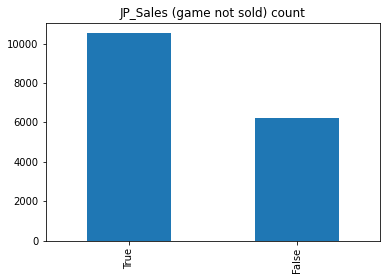

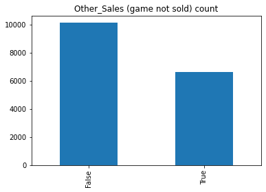

```python
(games['JP_Sales'] == 0).value_counts().plot.bar()
plt.title("JP_Sales (game not sold) count")
plt.show();
(games['Other_Sales'] == 0).value_counts().plot.bar()
plt.title("Other_Sales (game not sold) count")
plt.show();
```

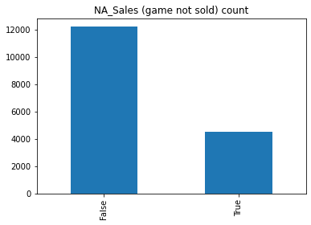

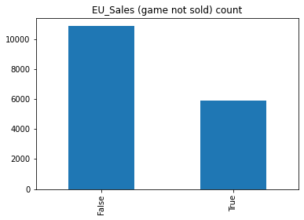

```python
(games['NA_Sales'] == 0).value_counts().plot.bar()
plt.title("NA_Sales (game not sold) count")
plt.show();
(games['EU_Sales'] == 0).value_counts().plot.bar()
plt.title("EU_Sales (game not sold) count")
plt.show();
```

# **Data Cleaning and Pre-Processing**

Based on how much of the data is missing and/or invalid here is what is being done to clean it:

- Replace missing years data with median year.
- Remove 2 null rows without a name & genre.
- Set unknown publisher to 'Unknown'.
- Set TBD user score to median.
- Replace Developer nan with 'Unknown'
- Replace unrated with U
- Replace E10+ with E
- Drop Critic Count & User Count
- Make categorical column for it a critic score was given or not
- Make User Scores Float Values

```python
#Proportion of missing values for a feature
df.isna().sum()/len(df)

#Remove 2 nan rows without a name & genre
temp = games[games['Name'].isna()].index.tolist()
games.drop(temp, axis=0, inplace=True)

#Replace nan years with median year
temp = int(games['Year_of_Release'].median())
games['Year_of_Release'].replace(np.nan, temp, inplace=True)

#set unknown publisher to 'other'
games['Publisher'].replace(np.nan, 'Unknown', inplace=True)

#Set TBD user score to median
games['User_Score'].replace('tbd', np.nan, inplace=True)
temp =  games['User_Score'].median()
games['User_Score'].replace(np.nan, temp , inplace=True)


#Replace Developer nan with unknown
games['Developer'].replace(np.nan, 'Unknown', inplace=True)

#Replace rating nan with U
games['Rating'].replace(np.nan, 'U', inplace=True)

#Replace E10+ with E
games['Rating'].replace('E10+', 'E', inplace=True)

#Drop Critic Count & User Count
games.drop(['User_Count','Critic_Count'], axis=1, inplace=True)

#Make Column for if a score was given or not.
games['Critic_Score'].replace(np.nan,0, inplace=True)
games['Scored'] = (games[['Critic_Score']] > 0).astype(int)
games['Critic_Score'].replace(0,np.nan, inplace=True)

#Change User Scores from String to Float
games['User_Score'] = games['User_Score'].astype(float)
```

# **Data Exploration and Visualization**

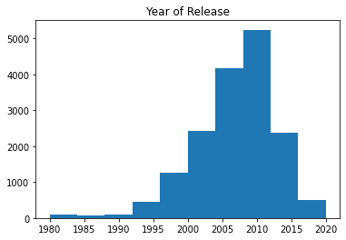

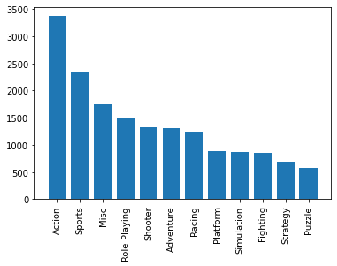

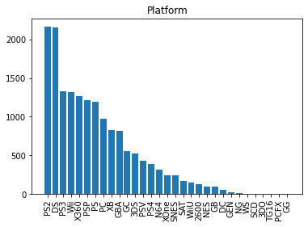

```python
plt.hist(games['Year_of_Release'])
plt.title('Year of Release')
plt.show();

temp = games['Genre'].value_counts()
plt.bar(temp.index,temp)
plt.xticks(rotation=90)
plt.show();

temp = games['Platform'].value_counts()
plt.bar(temp.index,temp)
plt.title('Platform')
plt.xticks(rotation=90)
plt.show();
```

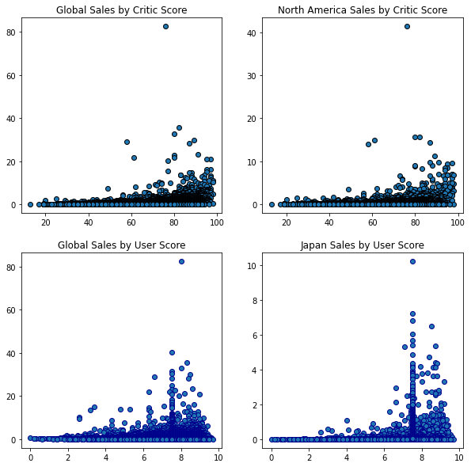

```python
fig = plt.figure(figsize=(10,10))

plt.subplot(2,2,1)
plt.scatter(games['Critic_Score'],games['Global_Sales'], edgecolors='black')
plt.title('Global Sales by Critic Score')

plt.subplot(2,2,2)
plt.scatter(games['Critic_Score'],games['NA_Sales'],edgecolors='black')
plt.title('North America Sales by Critic Score')

plt.subplot(2,2,3)
plt.scatter(games['User_Score'],games['Global_Sales'], edgecolors='darkblue')
plt.title('Global Sales by User Score')

plt.subplot(2,2,4)
plt.title('Japan Sales by User Score')
plt.scatter(games['User_Score'],games['JP_Sales'],edgecolors='darkblue');
```

Here is an examination of sales by critic, and user scores. It is noticiable where the tbd values were located in the user scores. All of the plots have a similar trend to them.

# **Machine Learning**

## **Model 1 - Linear Regression**

For the first model we will be using Linear Regression because it is simple to use and fast to predict. However, we need to be aware of overfitting if it occurs.

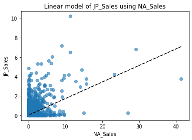

```python
X = df[['NA_Sales']].values
y = df['JP_Sales'].values

reg = LinearRegression()
reg.fit(X, y)
reg.intercept_
reg.coef_
predicted = reg.predict(X)

plt.title("Linear model of JP_Sales using NA_Sales")
plt.ylabel("JP_Sales")
plt.xlabel("NA_Sales")

plt.scatter(X,y, alpha=.6)
plt.plot(X,predicted,color='black',linestyle = 'dashed');
```

We have lots of values between 0 and 10 because, if we remember, sales are expressed as millions of units sold. We also notice that we have a few outliers and may cause problems for us.

By taking a look a at our r-squared value we see that it was around 20% which means that our model doesn't show much variability and it also means our model doesn't fit our data well.

```python
m, b = np.polyfit(df['JP_Sales'], df['NA_Sales'], 1)
print('intercept: {:.2f}'.format(b))
print('coefficient for JP_Sales: {:.2f}'.format(m))
print('r-squared value: {:.2f}'.format(reg.score(X,y)))
```

```
intercept: 0.17
coefficient for JP_Sales: 1.18
r-squared value: 0.20
```

#### Predicted vs Actual

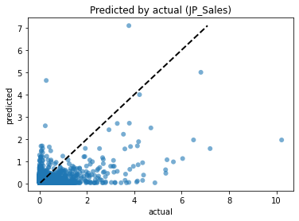

```python
#X = predicted
sns.scatterplot(df['JP_Sales'].values, predicted, edgecolor='None', alpha=0.6)
plt.title('Predicted by actual (JP_Sales)')
plt.ylabel("predicted")
plt.xlabel("actual")
low = predicted.min()
high = predicted.max()
plt.plot([low,high], [low,high], color='black', linestyle = 'dashed', linewidth=2);
```

#### Using the training and test data

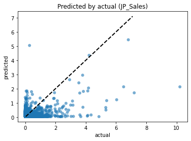

```python
X_train, X_test, y_train, y_test = train_test_split(X, y, test_size=0.3, random_state=42)

reg = LinearRegression()
reg.fit(X_train, y_train)

sns.scatterplot(y_train, reg.predict(X_train), edgecolor='None', alpha=0.6)
plt.title('Predicted by actual (JP_Sales)')
plt.ylabel("predicted")
plt.xlabel("actual")
low = predicted.min()
high = predicted.max()
plt.plot([low,high], [low,high], color='black', linestyle = 'dashed', linewidth=2);
```

```python
y_predict = reg.predict(X_test)
errors = y_test - y_predict
rmse = np.sqrt((errors**2).mean())
print("RMSE: {:.2f}".format(rmse))
```

```
RMSE: 0.28
```

We realized that the outliers in our data are throwing off our predicted values. So we are moving on and using a different model to better fit our data.

## Model 2 - Regression Tree

For the second model we thought maybe a regression tree would give us better results and we also don't have to scale the data.

```python
#genre = pd.get_dummies(games[['Genre']])
#genre = np.array(genre)
#genre = genre.unique()

#mae = mean absolute error

predictors = ['NA_Sales', 'EU_Sales', 'Other_Sales']
target = 'JP_Sales'

X = df[predictors].values
y = df[target].values

X_train, X_test, y_train, y_test = train_test_split(X, y, test_size=0.3, random_state=42)

reg = DecisionTreeRegressor(max_depth=2,criterion="mae")
reg.fit(X_train,y_train)
train_prediction = reg.predict(X_train)

treeData = export_graphviz(reg, feature_names=predictors, class_names=target, rounded=True, filled=True)

graph = graphviz.Source(treeData)
#graph
```

RMSE when tree has a Max Depth = 2

```python
## get predictions on test data

y_predict = reg.predict(X_test)
errors = y_test - y_predict
rmse = np.sqrt((errors**2).mean())
print("RMSE: {:.2f}".format(rmse))
```

```
RMSE: 0.30
```

Baseline without regularization

```python
## get predictions on test data
reg = DecisionTreeRegressor(criterion="mae")
reg.fit(X_train,y_train)
errors = y_test - y.mean()
rmse = np.sqrt((errors**2).mean())
print("RMSE: {:.2f}".format(rmse))
```

```
RMSE: 0.30
```

Model RMSE without regularization.

```python
## get predictions on test data

y_predict = reg.predict(X_test)
errors = y_test - y_predict
rmse = np.sqrt((errors**2).mean())
print("RMSE: {:.2f}".format(rmse))
```

```
RMSE: 0.34
```

#### Learning Curve

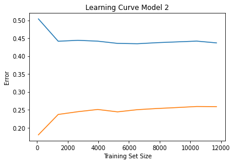

```python
te_errs = []
tr_errs = []
tr_sizes = np.linspace(100, X_train.shape[0], 10).astype(int)
for tr_size in tr_sizes:
  X_train1 = X_train[:tr_size,:]
  y_train1 = y_train[:tr_size]
  reg.fit(X_train1, y_train1)
  tr_predicted = reg.predict(X_train1)
  err = (tr_predicted != y_train1).mean()
  tr_errs.append(err)
  te_predicted = reg.predict(X_test)
  err = (te_predicted != y_test).mean()
  te_errs.append(err)

plt.title("Learning Curve Model 2")
plt.xlabel("Training Set Size")
plt.ylabel("Error")

sns.lineplot(x=tr_sizes, y=te_errs)
sns.lineplot(x=tr_sizes, y=tr_errs);
```

The graph above shows high bias and overfitting. Again, we are not getting the results we are looking for.

## Model 3 - kNN Classifier

```python
from sklearn.preprocessing import StandardScaler
from sklearn.neighbors import KNeighborsClassifier

temp = games['Critic_Score'].median()
games['Critic_Score'].replace(np.nan, temp, inplace=True)

X = games[['User_Score','Critic_Score','NA_Sales','EU_Sales','JP_Sales','Other_Sales']]
y = games['Genre']

X_train, X_test, y_train, y_test = train_test_split(X, y, test_size=0.3, random_state=42)

scaler = StandardScaler()
X_train = scaler.fit_transform(X_train)
X_test  = scaler.transform(X_test)

knn = KNeighborsClassifier(n_neighbors=3)
knn.fit(X_train, y_train)
predictions = knn.predict(X_test)
accuracy = (predictions == y_test).mean()
print("Accuracy: {:.2f}".format(accuracy))
```

```
Accuracy: 0.19
```

```python
for i in range(20):
    knn = KNeighborsClassifier(n_neighbors=i+1)
    knn.fit(X_train, y_train)
    predictions = knn.predict(X_test)
    accuracy = (predictions == y_test).mean()
    print(str(i+1) + "n Accuracy is: {:.2f}".format(accuracy))
```

```
1n Accuracy is: 0.17
2n Accuracy is: 0.18
3n Accuracy is: 0.19
4n Accuracy is: 0.19
5n Accuracy is: 0.21
6n Accuracy is: 0.20
7n Accuracy is: 0.21
8n Accuracy is: 0.21
9n Accuracy is: 0.21
10n Accuracy is: 0.22
11n Accuracy is: 0.23
12n Accuracy is: 0.22
13n Accuracy is: 0.22
14n Accuracy is: 0.22
15n Accuracy is: 0.23
16n Accuracy is: 0.23
17n Accuracy is: 0.23
18n Accuracy is: 0.23
19n Accuracy is: 0.23
20n Accuracy is: 0.22
```

To get an approxmiation of what we should set the parameter n for we ran a quick test of what the accuracy was for various different n nearest neighbors. For the neighbors selected it appears that n set between 15 to 19 will give a good result.

#### Forward Feature Selection

```python
ro, co = X_train.shape
knn = KNeighborsClassifier(n_neighbors=16)
temp_list = []
for i in range(co):
    temp = X_train[:,i:i+1]

    knn.fit(temp,y_train)

    temp2 = X_test[:,i:i+1]

    predictions = knn.predict(temp2)
    accuracy = (predictions == y_test).mean()
    print("feature" + "Accuracy: {:.2f}".format(accuracy))
    print(str(accuracy) + " , " + X.T.index[i])
    temp_list.append([accuracy,i])
# Make list , select first feature with best accuracy. [(i, Accuracy)].sort(Accuracy)
temp_list.sort(reverse=True)


co = temp_list[0][1]
temp_A = np.empty(shape=(X_train[:,co:co+1].shape))
temp_B = np.empty(shape=(X_test[:,co:co+1].shape))
accuracy = 0
for i in temp_list:
    co = temp_list[i[1]][1]
    temp_A = np.hstack([X_train[:,co:co+1],temp_A])
    temp_B = np.hstack([X_test[:,co:co+1],temp_B])
    knn.fit(temp_A, y_train)
    predictions = knn.predict(temp_B)

    if (((predictions == y_test).mean()) < accuracy):
        break;
    else:
        accuracy = (predictions == y_test).mean()
print('The features above continue to be selected until there is no more improvement in the model')
print('The final accuracy of selecting features is:')
print(accuracy)
```

```
featureAccuracy: 0.16
0.16068580542264752 , User_Score
featureAccuracy: 0.15
0.15291068580542264 , Critic_Score
featureAccuracy: 0.16
0.16228070175438597 , NA_Sales
featureAccuracy: 0.15
0.15490430622009568 , EU_Sales
featureAccuracy: 0.20
0.19577352472089316 , JP_Sales
featureAccuracy: 0.17
0.16965709728867623 , Other_Sales
The features above continue to be selected until there is no more improvement in the model
The final accuracy of selecting features is:
0.22567783094098884
```

The usage of sales data to select features does not appear to do a very good job of predicting the genre of video games. There is little improvement even when using a simple heuristic to select the number of nearest neighbors nor when using a non-exhaustive forward feature selection method.

## Model 4 - kMeans Clustering

```python
df = pd.get_dummies(df, columns=['Genre','Platform','Publisher'])
X=df[['Publisher_Namco Bandai Games',
          'Genre_Adventure',
          'Genre_Fighting',
          'Genre_Misc',
          'Genre_Platform',
          'Publisher_Nintendo',
          'Genre_Role-Playing',
          'Genre_Shooter','Platform_3DS','Genre_Sports']]
temp1 = X
kmeans = KMeans(n_clusters=3, random_state=0)
cluster_nums = kmeans.fit_predict(X)
cluster_nums[:10]
kmeans.inertia_
```

```
7352.491236511117
```

This k-means inertia tells how internally coherent the clusters are. Although not the smallest number, if we were to decrease it more it would increase the number of clusters and we want a balance of the two.

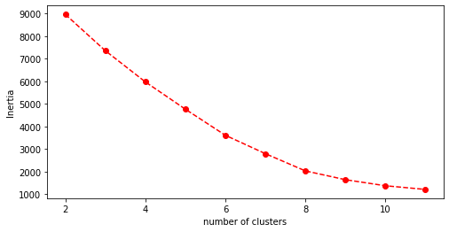

```python
iner = []
k = 3
kmeans = KMeans(n_clusters=k)
ks = list(range(2,12))
for k in ks:
    kmeans = KMeans(n_clusters=k)
    pred_labels = kmeans.fit_predict(X)
    iner.append(kmeans.inertia_)

plt.figure(figsize=(8,4))
plt.plot(ks, iner, 'ro--')
plt.xlabel('number of clusters')
plt.ylabel('Inertia');
```

In this graph, the value of inertia decreases as the number of clusters increase.

```python
#df.drop(['Name','Developer','User_Count','Critic_Count','Critic_Score','Rating','User_Score','Global_Sales','Other_Sales'], axis = 1)
games.drop('Rating', axis=1, inplace=True)
games.drop('Developer', axis=1, inplace=True)
games.drop('Publisher', axis=1, inplace=True)
games.drop('Genre', axis=1, inplace=True)
games.drop('Platform', axis=1, inplace=True)
games.drop('Name', axis=1, inplace=True)
games.drop('Critic_Score', axis=1, inplace=True)

range_n_clusters = list (range(2,26))
print ("Number of clusters from 2 to 26: \n", range_n_clusters)

for n_clusters in range_n_clusters:
    clusterer = KMeans (n_clusters=n_clusters)
    preds = clusterer.fit_predict(games)
    centers = clusterer.cluster_centers_

    score = silhouette_score (games, preds, metric='euclidean')
    print ("For n_clusters = {}, silhouette score is {})".format(n_clusters, score))
```

```
Number of clusters from 2 to 26:
 [2, 3, 4, 5, 6, 7, 8, 9, 10, 11, 12, 13, 14, 15, 16, 17, 18, 19, 20, 21, 22, 23, 24, 25]
For n_clusters = 2, silhouette score is 0.5283775451305481)
For n_clusters = 3, silhouette score is 0.4427224327779477)
For n_clusters = 4, silhouette score is 0.42084874804252176)
For n_clusters = 5, silhouette score is 0.4257922717992618)
For n_clusters = 6, silhouette score is 0.4318008551888776)
For n_clusters = 7, silhouette score is 0.407830271699709)
For n_clusters = 8, silhouette score is 0.36087325356300703)
For n_clusters = 9, silhouette score is 0.37247862861994696)
For n_clusters = 10, silhouette score is 0.36461992981329727)
For n_clusters = 11, silhouette score is 0.3680590472077055)
For n_clusters = 12, silhouette score is 0.33672552987646864)
For n_clusters = 13, silhouette score is 0.3432858419466216)
For n_clusters = 14, silhouette score is 0.3483622320797637)
For n_clusters = 15, silhouette score is 0.3575310190384097)
For n_clusters = 16, silhouette score is 0.349677193923973)
For n_clusters = 17, silhouette score is 0.3520105591430903)
For n_clusters = 18, silhouette score is 0.3487683985692587)
For n_clusters = 19, silhouette score is 0.34089661736375865)
For n_clusters = 20, silhouette score is 0.3366755961184755)
For n_clusters = 21, silhouette score is 0.34423533423178204)
For n_clusters = 22, silhouette score is 0.33658262256895444)
For n_clusters = 23, silhouette score is 0.3413821145737007)
For n_clusters = 24, silhouette score is 0.3255542661952227)
For n_clusters = 25, silhouette score is 0.3402954379240195)
```

For our model, we wanted to check the silhouette score and see how defined the clusters are. Ideally the score compared to structures the closer to 1 the number is the more defined the cluster is. So a 1 would be small groups of points vs a 0 which would just be a cloud of points with no defined structure. In our our case, the silhouette score shows a decently sized cluster.

# **Conclusions**

When focusing on the sales data we seemed to discover that the sales data was largely not predictive of many of the features of this data set. The linear models did not seem to do a great job of following the data, because of this we came across a number of challenges when refining our data. Our main goal to predict JP_Sales did not work out too well according to our first model. We tried other models and were still getting detrimental results. However, we learned a lot and it was a great chance to investigate how video games are connected to their sales.